# Tarea 4 Genomica funcional: REDES

### Red de coexpresion simulada

Simula una matriz de expresión con 20 genes en 6 condiciones diferentes

```r
set.seed(43)
genes <- c("gen1","gen2","gen3","gen4","gen5","gen6","gen7","gen8","gen9","gen10","gen11","gen12","gen13","gen14","gen15","gen16","gen17","gen18","gen19","gen20")
condiciones <- c("CondicionA","CondicionB","CondicionC","CondicionD","CondicionF","CondicionG")
valores <- c(sample(c(1:2000),20),sample(c(200:1000),20),sample(c(200:2500),20),sample(c(1000:1200),20),sample(c(1:500),20),sample(c(250:3000),20),sample(c(80:900),20))
matriz_expresion <- matrix(valores, nrow = 20, ncol = 6)
rownames(matriz_expresion) <- genes
colnames(matriz_expresion) <- condiciones

matriz_expresion <- t(matriz_expresion)

matriz_expresion
```

```
##            gen1 gen2 gen3 gen4 gen5 gen6 gen7 gen8 gen9 gen10 gen11 gen12 gen13
## CondicionA 1068  296 1732 1173   66  773 1498  440 1752  1869  1031   167  1666
## CondicionB  936  891  858  372  221  623  789  939  544   970   309   674   516
## CondicionC 2328  565  832 1710 1451 2345 2074  254  974  2246  1713  1637  1213
## CondicionD 1032 1166 1042 1164 1084 1183 1157 1043 1149  1168  1169  1066  1098
## CondicionF   74  349  376   30  184  196   45  432  346   120    69   103    38
## CondicionG 2156 2385 2387 2493 2954 1084 2593 1769 2732   921  2102  2727  2879
##            gen14 gen15 gen16 gen17 gen18 gen19 gen20
## CondicionA   863   470   839  1806  1513  1856  1335
## CondicionB   360   341   927   271   657   539   395
## CondicionC  1403  1220  2375  2287  1655  1377  2336
## CondicionD  1008  1020  1122  1148  1004  1068  1119
## CondicionF   447   220   194   345   473   336   252
## CondicionG  2747  1199   645  1182  1419  1153  2956
```

Calcula la correlación entre todos los pares de genes.

```r
head(cor(matriz_expresion, method = "pearson"))
```

```
##           gen1      gen2       gen3      gen4      gen5       gen6      gen7
## gen1 1.0000000 0.5122751 0.55243662 0.8987006 0.7724741 0.83940439 0.9475294
## gen2 0.5122751 1.0000000 0.69663662 0.6949520 0.8752303 0.10416824 0.6146847
## gen3 0.5524366 0.6966366 1.00000000 0.7970739 0.6386494 0.09213709 0.7802249
## gen4 0.8987006 0.6949520 0.79707385 1.0000000 0.8832672 0.62932892 0.9784627
## gen5 0.7724741 0.8752303 0.63864938 0.8832672 1.0000000 0.47897755 0.8110832
## gen6 0.8394044 0.1041682 0.09213709 0.6293289 0.4789776 1.00000000 0.6801110
##            gen8      gen9       gen10     gen11     gen12     gen13     gen14
## gen1  0.2915624 0.6120079  0.66242398 0.9185896 0.8431636 0.7352803 0.7809528
## gen2  0.9584082 0.7205688 -0.19864948 0.6299105 0.8614873 0.7325788 0.8250960
## gen3  0.6730755 0.9802355  0.22359642 0.7143780 0.6091624 0.9598757 0.7914657
## gen4  0.5163557 0.8707812  0.48033053 0.9900154 0.8798513 0.9335958 0.9424157
## gen5  0.7033699 0.7346290  0.08603105 0.8637430 0.9805862 0.7898464 0.9617810
## gen6 -0.1389062 0.1910154  0.78912678 0.7215915 0.5569120 0.3376970 0.4299878
##          gen15      gen16       gen17     gen18       gen19     gen20
## gen1 0.8711593  0.6880566  0.70618305 0.8363119  0.55460437 0.9243941
## gen2 0.5935771 -0.1453361 -0.09196856 0.1886778 -0.01932448 0.6243518
## gen3 0.4529589 -0.1282675  0.32318739 0.6101057  0.59001259 0.7206816
## gen4 0.8807399  0.3807033  0.64479158 0.8290610  0.62149358 0.9813745
## gen5 0.8458380  0.1961314  0.29632797 0.4962382  0.18767243 0.8792151
## gen6 0.8239327  0.9458012  0.81173887 0.7480431  0.50925294 0.6784761
```

Construye una red de coexpresión utilizando un umbral de correlación > 0.8.

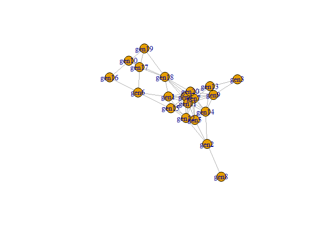

```r
matriz_adj <- (cor(matriz_expresion, method = "pearson") > 0.8) & (cor(matriz_expresion, method = "pearson") < 1)
coexpresion <- graph_from_adjacency_matrix(matriz_adj, mode = "undirected", diag = FALSE)
plot(coexpresion)
```

Calcula la distribución de grados.

```r
degree.distribution(coexpresion)
```

```
##  [1] 0.00 0.05 0.10 0.05 0.20 0.00 0.00 0.10 0.20 0.10 0.00 0.20
```

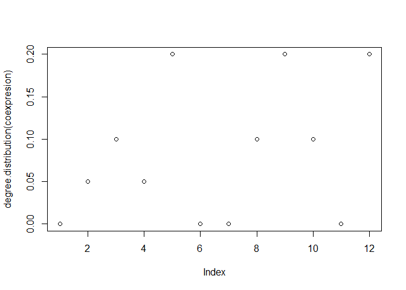

```r
plot(degree.distribution(coexpresion))
```

Identifica si hay módulos o agrupamientos de genes altamente correlacionados.

```r
cluster_louvain(coexpresion)
```

```
## IGRAPH clustering multi level, groups: 4, mod: 0.21
## + groups:
##   $`1`
##   [1] "gen1"  "gen6"  "gen15"
##
##   $`2`
##   [1] "gen2"  "gen5"  "gen8"  "gen12"
##
##   $`3`
##   [1] "gen3"  "gen4"  "gen7"  "gen9"  "gen11" "gen13" "gen14" "gen20"
##
##   $`4`
##   + ... omitted several groups/vertices
```

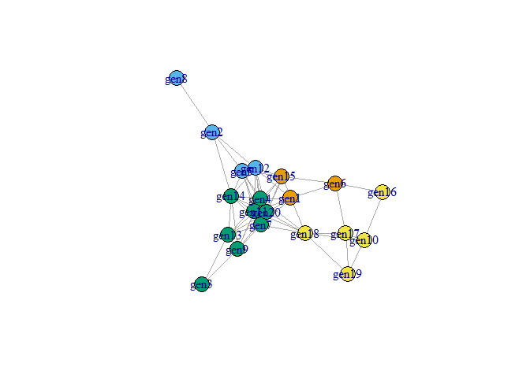

```r
plot(coexpresion, vertex.color = membership(cluster_louvain(coexpresion)))
```

```r
## Si se forman clusters de genes, este agrupamiento se hace por proximidad, como se puede apreciar en la visualizacion de la red clusterizada.
```

Visualiza la red y discute qué tipo de topología tiene.

La red tiene una topologia altamente conectada, con gran cantidad de nodos con degree alto y pocos con degree bajo, esto se debe al metodo que utilice para construir la red, asignando intervalos definidos para cada tratamiento, por lo que la probabilidad de correlacion es muy alta ya que se comportan de manera similar los genes en cada muestreo (por los limites establecidos), sin embargo al intentar con una matriz totalmente aleatoria era muy dificil obtener un valor de correlacion alto.

### Comparacion de redes

Construye dos redes:

- Una red aleatoria tipo Erdos-Rényi.

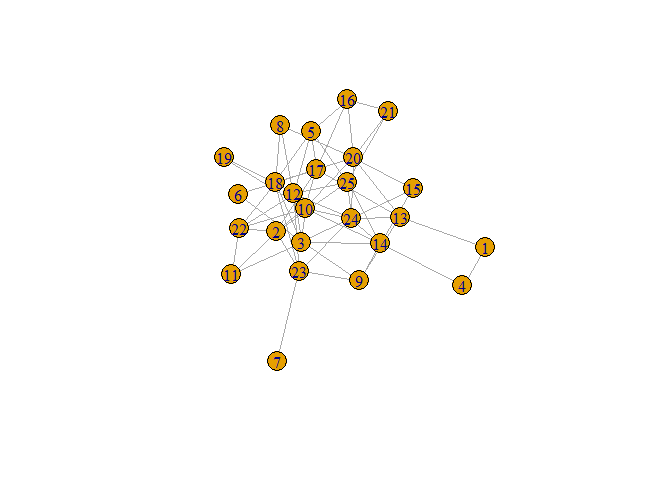

```r
erdos <- erdos.renyi.game(25, p=0.2)
plot(erdos)
```

- Una red tipo “scale-free” usando el modelo Barabási–Albert.

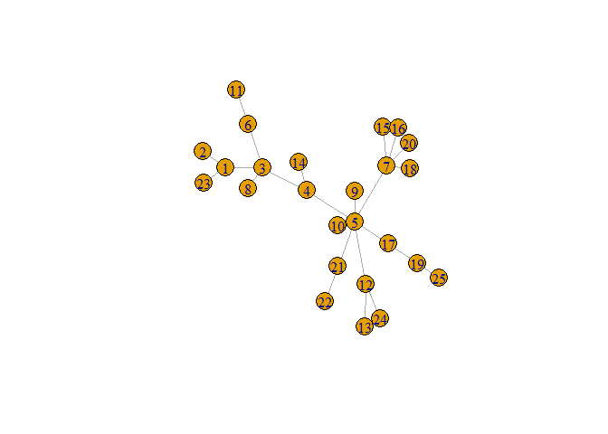

```r
bara <- barabasi.game(25, directed = FALSE)
plot(bara)
```

- Compara su grado promedio, distribución de grados, coeficiente de clusterización y diámetro.

```r
rerdos <- Red_propiedades(erdos)
rbara <- Red_propiedades(bara)

mean(rerdos$Degree)
```

```
## [1] 4.96
```

```r
mean(rbara$Degree)
```

```
## [1] 1.92
```

```r
rerdos$Degreee_distribution
```

```
##  [1] 0.00 0.04 0.16 0.16 0.08 0.12 0.16 0.04 0.20 0.04
```

```r
rbara$Degreee_distribution
```

```
## [1] 0.00 0.60 0.16 0.12 0.04 0.04 0.00 0.04
```

```r
rerdos$Diametro
```

```
## [1] 4
```

```r
rbara$Diametro
```

```
## [1] 7
```

Comparando el grado promedio podemos observar que con una red aleatoria se obtiene un promedio de conexiones alto, esto debido a la caracteristica de la distribucion de grados de este tipo de redes, donde hay una moda de degree y no hay una cola larga, a diferencia de la barabasi, donde hay mayor menor probabilidad de tener nodos con gran cantidad de conexiones, pero hay mayor variedad de degree, por lo que al observar en log log la distribucion observariamos una recta con pendiente 1 negativa. Por esto mismo al observar la distribucion de degree la tendencia de la red barabasi es de tener mayor frecuencia en nodos con poco degree y menor frecuencia en nodos con mayor degree, mientras que la red aleatoria tambien tiene una distribucion aleatoria de degree. Finalmente por esta caracteristica de poca densidad en barabasi la tendencia es de tener un mayor diametro, mientras que, la red aleatoria, debido a que mientras mayor son la cantidad de nodos con alto degree menor sera la distancia media entre nodos se puede observar que tiene un diametro menor.

Las redes biologicas se comportan como el modelo barabasi, ya que tienen una mayor robustes ante perturbaciones azarosas, debido a que tener alta frecuencia de nodos con degree mayor seria comprometer la red ante perturbaciones ya que la probabilidad de atacar nodos importantes de la red es mayor, por lo que evolutivamente la tendencia de las redes ha sido priorizar una distribucion de degree tipo barabasi aunque esto represente aumentar la distancia media entre nodos.